# Assignment 4

Maya Stein

2025-11-21

# Set Up & Introduction

## The Data

- For this assignment, I will be analyzing data from the barroso2021 data set. This data set is from the psymetadata package, and it observes the relationship between math achievement and math anxiety (https://psycnet.apa.org/record/2020-80018-001)
- These Variables Will Be The Focus of This Assignment:
  - Grade: participants included were in grades 1 through 6
  - Math Ability: categorized by low or not low
  - Effect Size: where the absolute value was calculated, so values range from 0 (no effect) to 1 (strongest possible effect)

## Sample Size By Grade

Grade 5 has the biggest sample, as well as students for both high and low math ability conditions. Grade 6 has the lowest sample size, which likely explains the lack of samples for students with low math abilities. The absence/presence of low math ability students in the other grades is not well understood at this time. This will likely play a role in observations of effect size.

| grade | n |
| --- | --- |
| 1 | 68 |
| 2 | 89 |
| 3 | 116 |
| 4 | 99 |
| 5 | 355 |
| 6 | 20 |

Note: only groups 2 and 5 have students in the low math ability condition

## Range of Effect Size Values

Effect sizes are organized on a scale from “no effect” to “large effect”:

- No effect: 0.0 until 0.2
- Small effect: 0.2 until 0.5
- Medium effect: 0.5 until 0.8
- Large effect: 0.8 and above

## Effect Size Distribution

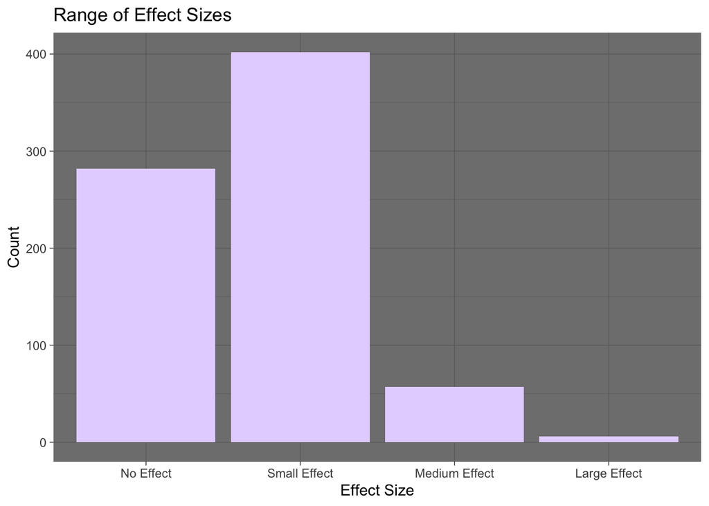

# Visualizations & Analysis

## Sample Size - Grouped by Grade and Math Ability

```r
#Change colors and save the graph
visualization1 <- sample_size_visualization + scale_fill_manual(values = c("Avg_Plus_Math_Ability" = "#78FFEC", "Low_Math_Ability" = "#FF99EA"))
```

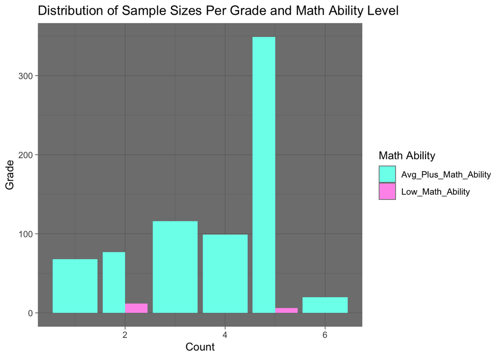

```r
visualization1
```